# 08 Ecoregion Patterns in HUC8 Metabolism Allometry

```r
knitr::opts_chunk$set(echo = F,
                      warning = F,
                      message = F)
```

## Goal

This notebook asks whether HUC8-scale GPP and ER allometries vary systematically across broad Level I ecoregions. The intent is descriptive stratification: ecoregions are used to summarize where scaling patterns occur, not to infer that ecoregion membership causes those scaling patterns.

**My take:**

## Build or read the HUC8 ecoregion lookup

This section uses a lightweight API route. It queries the ArcGIS REST service for Level I North American terrestrial ecoregions, assigns each HUC8 to the Level I ecoregion containing its point-on-surface, and saves only the small HUC8 lookup table. The ecoregion polygons themselves are not saved.

**My take:**

| l1_code | l1_ecoregion | n |
| --- | --- | --- |
| 8 | Eastern Temperate Forests | 764 |
| 9 | Great Plains | 568 |
| 10 | North American Deserts | 314 |
| 6 | Northwestern Forested Mountains | 213 |
| 5 | Northern Forests | 140 |
| 11 | Mediterranean California | 61 |
| 7 | Marine West Coast Forests | 40 |
| NA | NA | 38 |
| 13 | Temperate Sierras | 18 |
| 12 | Southern Semi-Arid Highlands | 10 |
| 15 | Tropical Humid Forests | 4 |

## How do GPP and ER slopes vary across Level I ecoregions?

**My take:**

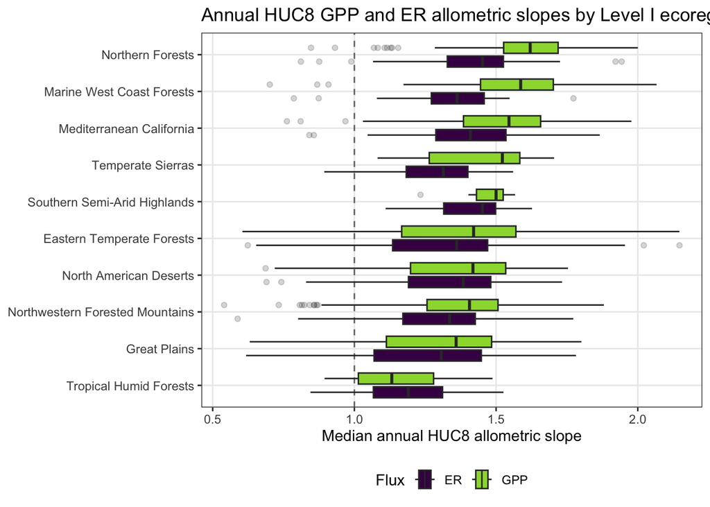

## Where do GPP and ER scaling rules diverge?

Positive values mean GPP has the steeper annual allometric slope. Negative values mean ER has the steeper annual allometric slope.

**My take:**

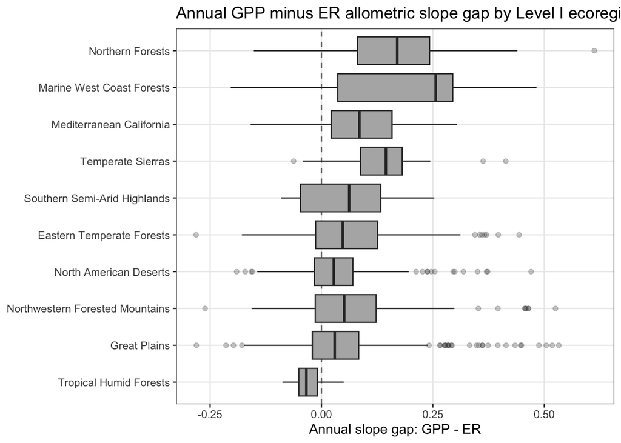

## Are ecoregion patterns seasonal?

This heatmap shows the median monthly HUC8 allometric slope within each Level I ecoregion. It is a compact way to see whether ecoregion separation is persistent or season-specific.

**My take:**

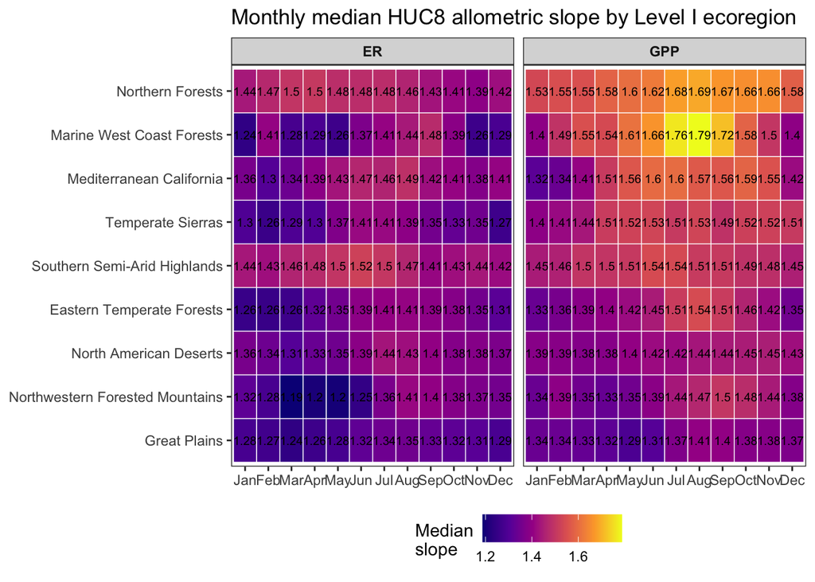

## Do ecoregion differences persist after excluding compromised HUC8s?

This is a quick sensitivity check. “Compromised” follows the centroid-filter diagnostics from the 06 workflow. It does not mean the HUC8 is unusable; it only flags HUC8s where removed reaches may have enough leverage to matter.

**My take:**

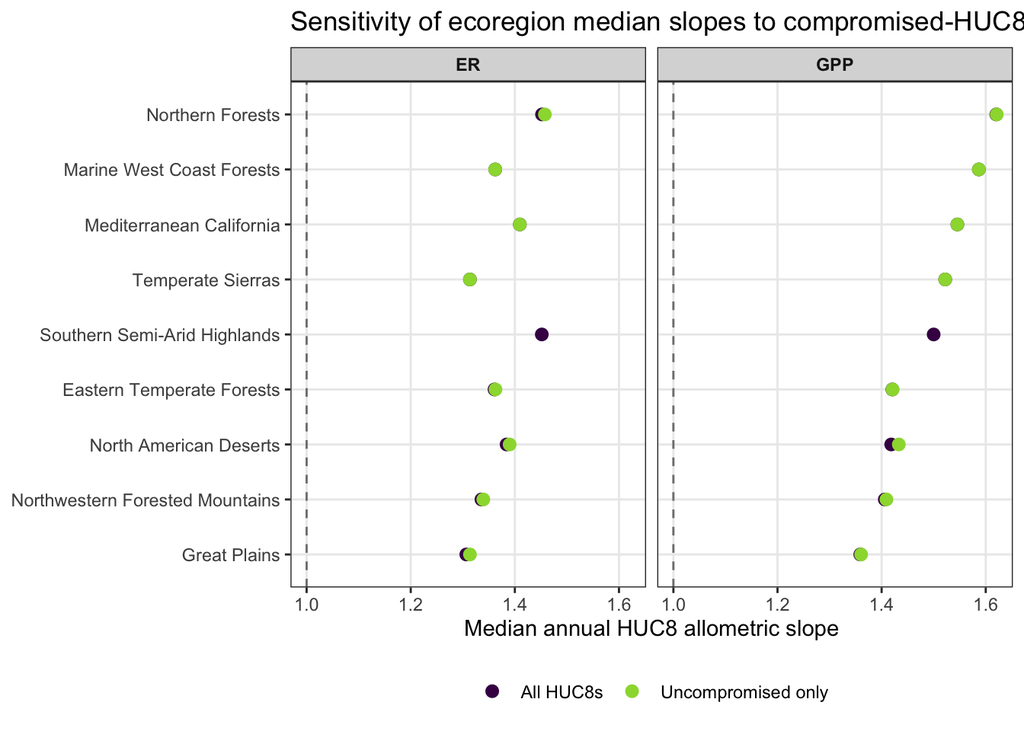

**My take:**

## Compact summary tables

**My take:**

| l1_code | l1_ecoregion | metabolism | n_huc8 | n_compromised_huc8 | pct_compromised_huc8 | median_annual_slope | p25_annual_slope | p75_annual_slope | median_annual_r2 | median_pct_coherent_months |
| --- | --- | --- | --- | --- | --- | --- | --- | --- | --- | --- |
| 15 | Tropical Humid Forests | ER | 4 | 0 | 0.00 | 1.19 | 1.07 | 1.31 | 0.83 | 62.50 |
| 9 | Great Plains | ER | 533 | 21 | 3.94 | 1.31 | 1.07 | 1.45 | 0.89 | 100.00 |
| 13 | Temperate Sierras | ER | 17 | 0 | 0.00 | 1.31 | 1.18 | 1.40 | 0.87 | 100.00 |
| 6 | Northwestern Forested Mountains | ER | 200 | 8 | 4.00 | 1.34 | 1.17 | 1.43 | 0.88 | 100.00 |
| 8 | Eastern Temperate Forests | ER | 672 | 18 | 2.68 | 1.36 | 1.13 | 1.47 | 0.91 | 100.00 |
| 7 | Marine West Coast Forests | ER | 26 | 0 | 0.00 | 1.36 | 1.27 | 1.46 | 0.89 | 95.83 |
| 10 | North American Deserts | ER | 303 | 12 | 3.96 | 1.38 | 1.19 | 1.48 | 0.87 | 100.00 |
| 11 | Mediterranean California | ER | 44 | 0 | 0.00 | 1.41 | 1.29 | 1.53 | 0.87 | 100.00 |
| 12 | Southern Semi-Arid Highlands | ER | 7 | 3 | 42.86 | 1.45 | 1.32 | 1.50 | 0.88 | 100.00 |
| 5 | Northern Forests | ER | 96 | 18 | 18.75 | 1.45 | 1.33 | 1.53 | 0.90 | 100.00 |
| 15 | Tropical Humid Forests | GPP | 4 | 0 | 0.00 | 1.13 | 1.01 | 1.28 | 0.82 | 66.67 |
| 9 | Great Plains | GPP | 533 | 21 | 3.94 | 1.36 | 1.11 | 1.48 | 0.91 | 100.00 |
| 6 | Northwestern Forested Mountains | GPP | 201 | 8 | 3.98 | 1.41 | 1.26 | 1.51 | 0.88 | 100.00 |
| 10 | North American Deserts | GPP | 303 | 12 | 3.96 | 1.42 | 1.20 | 1.53 | 0.88 | 100.00 |
| 8 | Eastern Temperate Forests | GPP | 672 | 18 | 2.68 | 1.42 | 1.17 | 1.57 | 0.90 | 100.00 |
| 12 | Southern Semi-Arid Highlands | GPP | 7 | 3 | 42.86 | 1.50 | 1.43 | 1.53 | 0.91 | 100.00 |
| 13 | Temperate Sierras | GPP | 17 | 0 | 0.00 | 1.52 | 1.26 | 1.58 | 0.90 | 100.00 |
| 11 | Mediterranean California | GPP | 45 | 0 | 0.00 | 1.55 | 1.39 | 1.66 | 0.85 | 100.00 |
| 7 | Marine West Coast Forests | GPP | 26 | 0 | 0.00 | 1.59 | 1.45 | 1.70 | 0.91 | 100.00 |
| 5 | Northern Forests | GPP | 96 | 18 | 18.75 | 1.62 | 1.53 | 1.72 | 0.93 | 100.00 |

| l1_code | l1_ecoregion | n_huc8 | n_compromised_huc8 | pct_compromised_huc8 | median_gpp_slope | median_er_slope | median_slope_gap_gpp_minus_er | p25_slope_gap_gpp_minus_er | p75_slope_gap_gpp_minus_er | pct_gpp_slope_greater_than_er |
| --- | --- | --- | --- | --- | --- | --- | --- | --- | --- | --- |
| 15 | Tropical Humid Forests | 4 | 0 | 0.00 | 1.13 | 1.19 | -0.03 | -0.05 | -0.01 | 25.00 |
| 10 | North American Deserts | 303 | 12 | 3.96 | 1.42 | 1.38 | 0.03 | -0.02 | 0.07 | 67.00 |
| 9 | Great Plains | 533 | 21 | 3.94 | 1.36 | 1.31 | 0.03 | -0.02 | 0.08 | 66.60 |
| 8 | Eastern Temperate Forests | 672 | 18 | 2.68 | 1.42 | 1.36 | 0.05 | -0.01 | 0.13 | 70.24 |
| 6 | Northwestern Forested Mountains | 200 | 8 | 4.00 | 1.41 | 1.34 | 0.05 | -0.01 | 0.12 | 70.50 |
| 12 | Southern Semi-Arid Highlands | 7 | 3 | 42.86 | 1.50 | 1.45 | 0.06 | -0.05 | 0.13 | 57.14 |
| 11 | Mediterranean California | 44 | 0 | 0.00 | 1.54 | 1.41 | 0.09 | 0.02 | 0.16 | 77.27 |
| 13 | Temperate Sierras | 17 | 0 | 0.00 | 1.52 | 1.31 | 0.14 | 0.09 | 0.18 | 88.24 |
| 5 | Northern Forests | 96 | 18 | 18.75 | 1.62 | 1.45 | 0.17 | 0.08 | 0.24 | 89.58 |
| 7 | Marine West Coast Forests | 26 | 0 | 0.00 | 1.59 | 1.36 | 0.26 | 0.04 | 0.29 | 80.77 |

## Initial interpretation notes

Use this section as a running scratchpad for interpretation after inspecting the figures and tables.

**My take:**

```
## Time difference of 4.235639 mins
```